# wk02_0304_

Justine

2021/3/4

## inclass

- google [google](https://www.google.com/?hl=zh_tw)
- adobe
  - red
  - orange
  - yellow
- cat

  1.cat1

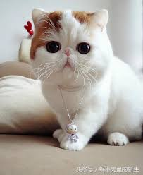

  2.cat2

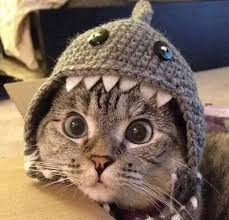

  3. ```
     連假放完，年算過了。
     昨天去球館。與一位68歲牙醫球友聊天。他仍在工作，最近才換了執業執照(打算繼續幹)。
     他樂善好施，兢兢業業，看起來生活充滿樂趣。時常在群組po旅遊照片。他的天空，陽光普照，單純的湛藍。
     我則有點提不起勁 。又老了一歲。
     身體的折磨告訴我 ，世界末日真的存在 ， 太陽會燒完自己 ，這一切終將消失。我還要在這樣的意識下繼續工作多久？
     ```

### arithmetic

+-*/  
%%餘數  
%/%商數  
**

```r
1+2
```

```
## [1] 3
```

```r
3-4
```

```
## [1] -1
```

```r
5*6
```

```
## [1] 30
```

```r
7/8
```

```
## [1] 0.875
```

```r
7%%8
```

```
## [1] 7
```

```r
2^10
```

```
## [1] 1024
```

### function

```r
abs(-456)
```

```
## [1] 456
```

```r
abs(56)
```

```
## [1] 56
```

```r
round(23.45,1)
```

```
## [1] 23.4
```

```r
floor(23.45)
```

```
## [1] 23
```

```r
ceiling(23.45)
```

```
## [1] 24
```

> block quote  
> * unordered list  
> * item 2  
> + sub-item 1  
> + sub-item 2
1. ordered list
2. item 2
- sub-item 1
- sub-item 2

| Table Header | Second Header |
| --- | --- |
| Table Cell | Cell 2 |
| Cell 3 | Cell 4 |

## 是非題

(O)1.R studio的Console視窗主要是編輯R語言程式碼,儲存,最後再執行的視窗  
(X)3.在Workspace視窗,如果選Environment標籤,可以在此看到Console視窗所有執行指令的紀錄  
(X)5.下列3個指令的執行結果是一樣的  
>x=10或>x<-10或>10->x

## 是非題

(O)2.R語言有支援直譯器(Interpretor),可以在Console視窗直接輸入指令,同時獲得執行結果  
()4.一個完整的R程式,即使在Source editor區編輯,其執行的非圖形資料結果,將是在Console視窗中顯示

## 複選題

(AD)1.哪幾個函數可以保存Console視窗執行過的指令  
(A)save() (B)save.image()  
(C)load() (D)savehistory() (E)getwd()

## 實作題

1.請研究R Studio視窗右上角的Workspace視窗,說明下列標籤的功能:  
a.Environment:用來記載目前變數的數值,方便查看目前變數的狀況  
b.History:所有在Console執行過程式碼的歷史記錄  
c.To Console:執行程式碼  
d.To Source:載入編寫的函数  
2.請研究R Studio視窗右下角的Files/Plots視窗,說明下列標籤的功能:  
a.Files: b.Export:

```r
5**2
```

```
## [1] 25
```

```r
5^3
```

```
## [1] 125
```

```r
9**(1/2)
```

```
## [1] 3
```

```r
125**(1/3)
```

```
## [1] 5
```

```r
9%%7
```

```
## [1] 2
```

```r
9%/%7
```

```
## [1] 1
```

```r
abs(-100)
```

```
## [1] 100
```

```r
round(47.85)
```

```
## [1] 48
```

```r
round(47.85,1)
```

```
## [1] 47.9
```

```r
floor(-100.297)
```

```
## [1] -101
```

```r
ceiling(-100.297)
```

```
## [1] -100
```

### 上課筆記

Tools->Global option->UTF-8  
設定->Preview in view pane->viewer  
img src=‘網址’ /img  
size=字體大小 width=圖片大小  
font color=‘色號’ /font  
abs()絕對值  
round(number,小數點後幾位)  
round()四捨五入  
floor()小於等於最近整數(無條件捨去)  
ceiling()大於等於最近整數(無條件進位) 表格:線要對齊

### 補充筆記

ls()顯示當前已有的所有變量 rm()刪除相應物件 head()檢視相應物件 getwd()回傳目前的工作路徑 setwd()指定工作路徑 q()離開 save(物件名稱, file=“檔名.rdata”) load(“檔名.rdata”)載入檔案